# Limpieza y análisis del *dataset TITANIC*

Ander Elkoroaristizabal

Junio 2021

# 1. Descripción del dataset

El conjunto de datos que estudiaremos es el [*Titanic dataset*](https://www.kaggle.com/c/titanic/data). El objetivo primordial de este *dataset* es la creación de un modelo que prediga que pasajeros sobrevivieron al hundimiento del Titanic e indique cuales son las variables más importantes para la predicción.

Este *dataset* resulta especialmente atractivo por lo interesante del tema, la variedad en las variables y la cantidad de estudios y discusiones sobre él que podemos encontrar, incluso en la propia [página de discusiones de la competición en Kaggle](https://www.kaggle.com/c/titanic/discussion).

El conjunto de datos “completo” tal y como se incluye en [Kaggle](https://www.kaggle.com) viene ya dividido en dos subconjuntos: uno de entrenamiento, denominado “train.csv” y otro de evaluación, denominado “test.csv”. Al conjunto de evaluación le falta la columna `Survived` que se debe predecir. Esto se debe a que sobre este segundo conjunto está pensado para que efectuemos nuestras predicciones sobre él y subamos estas predicciones a la [competición](https://www.kaggle.com/c/titanic/overview) a la que pertenece. En consecuencia nosotros preprocesaremos de manera independiente ambos conjuntos (de forma que no se filtre información de evaluación a entrenamiento), pero sólo podremos utilizar el primer conjunto para analizar, aunque mantendremos la nomenclatura original (conjunto de entrenamiento y de evaluación).

La hoja de ruta es la siguiente:

1. Limpiaremos ambos conjuntos de datos de manera independiente.
2. Analizaremos las variables explicativas en el conjunto de entrenamiento y su nivel de relación con la variable a predecir, `Survived`.
3. Crearemos un modelo de clasificación con el conjunto de entrenamiento, y usaremos la validación cruzada para evaluar su rendimiento.
4. Obtendremos las variables más importantes para la predicción a partir de este último modelo.

El conjunto contiene 10 variables además de la variable respuesta `Survived`, con 891 registros en el conjunto de entrenamiento y 418 registros en el conjunto de evaluación.

A continuación mostramos el diccionario de datos:

| Variable | Definición | Claves |
| --- | --- | --- |
| survival | Variable binaría indicadora de la supervivencia. | 1 = Sí, 0 = No. |
| pclass | Clase del billete de embarque. | 1 = Primera clase, 2 = Segunda clase, 3 = Tercera clase |
| sex | Sexo. |  |
| Age | Edad, en años. |  |
| sibsp | Número de hermanos/esposas también en el Titanic. |  |
| parch | Número de padres/hijos también en el Titanic. |  |
| ticket | Código alfanumérico del billete. |  |
| fare | Precio del billete. |  |
| cabin | Código alfanumérico de cabina. |  |
| embarked | Puerto de embarque. | C = Cherbourg, Q = Queenstown, S = Southampton |

# 2. Integración y selección de los datos de interés a analizar.

No necesitamos hacer integración ninguna, dado que como ya hemos comentado disponemos sólo de dos conjuntos de datos, uno de entrenamiento y otro de evaluación, y debemos tratarlos de manera independiente. Cargamos los datos:

```r
# Entrenamiento
train_df <- read.csv("data/train.csv")
# Evaluación
test_df <- read.csv("data/test.csv")
```

Verificamos la unicidad de los atributos individuales de ambos conjuntos, es decir todos los atributos excepto el identificador. Como podemos ver todos los registros son únicos:

```r
# Entrenamiento
any(duplicated(train_df[,-1]))
```

```
## [1] FALSE
```

```r
# Evaluación
any(duplicated(test_df[,-1]))
```

```
## [1] FALSE
```

Respecto a la selección de datos:

- Como no nos interesa restringirnos a un grupo en particular mantendremos en este punto todos los registros.
- Nos quedaremos también todas las variables, dado que todas parece que puedan estar relacionadas con el objetivo, y eliminaremos las que no nos sean útiles más adelante en un proceso de selección de variables.

# 3. Limpieza de datos

## 3.1 Busqueda de valores nulos encubiertos

Como primer punto de la limpieza de datos y de cara a identificar los valores desconocidos que pueda haber no identificados como tales (como `NA`), analizaremos la estructura del conjunto de datos, haremos las conversiones de variables necesarias y obtendremos una descripción preliminar de los datos.

La estructura de los datos de entrenamiento y de evaluación tal y como los lee `R` es como sigue:

```r
# Entrenamiento
str(train_df)
```

```
## 'data.frame':    891 obs. of  12 variables:
##  $ PassengerId: int  1 2 3 4 5 6 7 8 9 10 ...
##  $ Survived   : int  0 1 1 1 0 0 0 0 1 1 ...
##  $ Pclass     : int  3 1 3 1 3 3 1 3 3 2 ...
##  $ Name       : chr  "Braund, Mr. Owen Harris" "Cumings, Mrs. John Bradley (Florence Briggs Thayer)" "Heikkinen, Miss. Laina" "Futrelle, Mrs. Jacques Heath (Lily May Peel)" ...
##  $ Sex        : chr  "male" "female" "female" "female" ...
##  $ Age        : num  22 38 26 35 35 NA 54 2 27 14 ...
##  $ SibSp      : int  1 1 0 1 0 0 0 3 0 1 ...
##  $ Parch      : int  0 0 0 0 0 0 0 1 2 0 ...
##  $ Ticket     : chr  "A/5 21171" "PC 17599" "STON/O2. 3101282" "113803" ...
##  $ Fare       : num  7.25 71.28 7.92 53.1 8.05 ...
##  $ Cabin      : chr  "" "C85" "" "C123" ...
##  $ Embarked   : chr  "S" "C" "S" "S" ...
```

```r
# Evaluación
str(test_df)
```

```
## 'data.frame':    418 obs. of  11 variables:
##  $ PassengerId: int  892 893 894 895 896 897 898 899 900 901 ...
##  $ Pclass     : int  3 3 2 3 3 3 3 2 3 3 ...
##  $ Name       : chr  "Kelly, Mr. James" "Wilkes, Mrs. James (Ellen Needs)" "Myles, Mr. Thomas Francis" "Wirz, Mr. Albert" ...
##  $ Sex        : chr  "male" "female" "male" "male" ...
##  $ Age        : num  34.5 47 62 27 22 14 30 26 18 21 ...
##  $ SibSp      : int  0 1 0 0 1 0 0 1 0 2 ...
##  $ Parch      : int  0 0 0 0 1 0 0 1 0 0 ...
##  $ Ticket     : chr  "330911" "363272" "240276" "315154" ...
##  $ Fare       : num  7.83 7 9.69 8.66 12.29 ...
##  $ Cabin      : chr  "" "" "" "" ...
##  $ Embarked   : chr  "Q" "S" "Q" "S" ...
```

Como podemos ver hay muchas variables cuyo tipo debemos cambiar:

- `Survived`, `Sex`, `Cabin` (dado que mucha gente comparte cabina), y `Embarked` deberían ser factores.
- `Ticket` también debería ser un factor, dado que no es único, si no que hay pasajeros que comparten un mismo billete (y no es porque sean `NA` o `''`):

```r
table(duplicated(train_df['Ticket']))
```

```
##
## FALSE  TRUE
##   681   210
```

```r
head(train_df[duplicated(train_df['Ticket']), c('Ticket')])
```

```
## [1] "349909"       "CA 2144"      "19950"        "11668"        "347082"
## [6] "S.O.C. 14879"
```

- `Pclass` debería ser un factor ordenado donde el nivel más bajo fuese 3 y el más alto 1.
- `SibSp` y `Parch` deberían ser enteros, si bien este cambio no suele impactar demasiado en los análisis.

Mantendremos `PassengerId` como número, siendo conscientes de que es en realidad la clave primaria de nuestros datos.

Hacemos las conversiones necesarias:

```r
# Entrenamiento
train_df[,"Survived"] = factor(train_df[,"Survived"],
                               levels = c(0,1),
                               labels = c(FALSE, TRUE))
train_df[, c('Sex', 'Ticket', 'Cabin', 'Embarked')] =
  lapply(train_df[, c('Sex', 'Ticket', 'Cabin', 'Embarked')], factor)
train_df[, 'Pclass'] = factor(train_df[,'Pclass'], ordered = TRUE, levels = c(3,2,1))
train_df[, c('SibSp', 'Parch')] = lapply(train_df[, c('SibSp', 'Parch')], as.integer)
# Evaluación
test_df[, c('Sex', 'Ticket', 'Cabin', 'Embarked')] =
  lapply(test_df[, c('Sex', 'Ticket', 'Cabin', 'Embarked')], factor)
test_df[, 'Pclass'] = factor(test_df[,'Pclass'], ordered = TRUE, levels = c(3,2,1))
test_df[, c('SibSp', 'Parch')] = lapply(test_df[, c('SibSp', 'Parch')], as.integer)
```

Analizamos ahora por encima los datos que tenemos según su tipo.

Comenzamos por las variables numéricas:

```r
# Entrenamiento
summary(Filter(is.numeric, train_df[,-1]))
```

```
##       Age            SibSp           Parch             Fare
##  Min.   : 0.42   Min.   :0.000   Min.   :0.0000   Min.   :  0.00
##  1st Qu.:20.12   1st Qu.:0.000   1st Qu.:0.0000   1st Qu.:  7.91
##  Median :28.00   Median :0.000   Median :0.0000   Median : 14.45
##  Mean   :29.70   Mean   :0.523   Mean   :0.3816   Mean   : 32.20
##  3rd Qu.:38.00   3rd Qu.:1.000   3rd Qu.:0.0000   3rd Qu.: 31.00
##  Max.   :80.00   Max.   :8.000   Max.   :6.0000   Max.   :512.33
##  NA's   :177
```

```r
# Evaluación
summary(Filter(is.numeric, test_df[,-1]))
```

```
##       Age            SibSp            Parch             Fare
##  Min.   : 0.17   Min.   :0.0000   Min.   :0.0000   Min.   :  0.000
##  1st Qu.:21.00   1st Qu.:0.0000   1st Qu.:0.0000   1st Qu.:  7.896
##  Median :27.00   Median :0.0000   Median :0.0000   Median : 14.454
##  Mean   :30.27   Mean   :0.4474   Mean   :0.3923   Mean   : 35.627
##  3rd Qu.:39.00   3rd Qu.:1.0000   3rd Qu.:0.0000   3rd Qu.: 31.500
##  Max.   :76.00   Max.   :8.0000   Max.   :9.0000   Max.   :512.329
##  NA's   :86                                        NA's   :1
```

Podemos ver que sólo a un registro perteneciente al conjunto de evaluación le falta información de `Fare`. Por otra parte también vemos que 263 registros (177 de entrenamiento y 86 de evaluación) no tienen la edad informada. Esto sí que es un posible problema que necesitaremos subsanar, debido a la cantidad de registros afectados y a que una posible política de supervivencia prioritaria aplicada durante el hundimiento del Titanic podría ser “Mujeres y niños primero”. Del resto de variables sólo la cantidad de ceros en `Parch` nos hace pensar que puedan ser valores desconocidos, pero teniendo en cuenta el significado de la variable parece normal.

Estudiamos también los factores:

```r
# Entrenamiento
summary(Filter(is.factor, train_df))
```

```
##   Survived   Pclass      Sex           Ticket            Cabin     Embarked
##  FALSE:549   3:491   female:314   1601    :  7              :687    :  2
##  TRUE :342   2:184   male  :577   347082  :  7   B96 B98    :  4   C:168
##              1:216                CA. 2343:  7   C23 C25 C27:  4   Q: 77
##                                   3101295 :  6   G6         :  4   S:644
##                                   347088  :  6   C22 C26    :  3
##                                   CA 2144 :  6   D          :  3
##                                   (Other) :852   (Other)    :186
```

```r
# Evaluación
summary(Filter(is.factor, test_df))
```

```
##  Pclass      Sex           Ticket                Cabin     Embarked
##  3:218   female:152   PC 17608:  5                  :327   C:102
##  2: 93   male  :266   113503  :  4   B57 B59 B63 B66:  3   Q: 46
##  1:107                CA. 2343:  4   A34            :  2   S:270
##                       16966   :  3   B45            :  2
##                       220845  :  3   C101           :  2
##                       347077  :  3   C116           :  2
##                       (Other) :396   (Other)        : 80
```

Vemos valores `NA` encubiertos en las variables `Cabin` y `Embarked` que convertimos en `NA`, tras lo cual eliminamos el nivel que les corresponde:

```r
# Entrenamiento
## Cabin
train_df[train_df['Cabin']=='', 'Cabin']  = NA
train_df[,'Cabin'] = droplevels(train_df[,'Cabin'])
## Embarked
train_df[train_df['Embarked']=='', 'Embarked']  = NA
train_df[,'Embarked'] = droplevels(train_df[,'Embarked'])

# Evaluación, variable `Cabin` sólo:
test_df[test_df['Cabin']=='', 'Cabin']  = NA
test_df[,'Cabin'] = droplevels(test_df[,'Cabin'])
```

## 3.2 Estudio de los valores extremos

Estudiamos ahora los posibles valores extremos que pueda haber en cada subconjunto de datos de manera independiente. Realizamos para ello un diagrama de caja de cada una de las variables numéricas con la librería `ggplot2`. Definimos primero la función a utilizar para cada una de las variables y ambos conjuntos por separado:

```r
library(ggplot2)
PrettyBoxplot= function(var, df){
  bp = ggplot(df, aes(y = get(var))) +
    geom_boxplot(outlier.colour="blue", outlier.size = 1) +
    ggtitle(paste("Diagrama de caja\n de la variable", var)) + ylab("") +
    theme(plot.title = element_text(hjust = 0.5))
  return(bp)
}
```

Los diagramas de caja de las variables numéricas en el conjunto de entrenamiento son los que siguen:

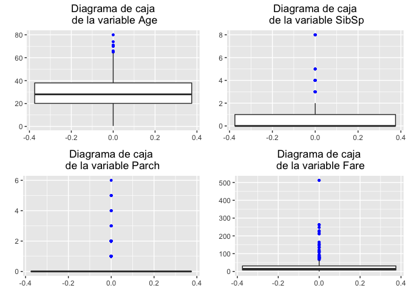

```r
gridExtra::grid.arrange(grobs = lapply(colnames(Filter(is.numeric, train_df[,-1])),
                                       df = train_df,  PrettyBoxplot))
```

Los diagramas de caja de las variables numéricas en el conjunto de evaluación son los que siguen:

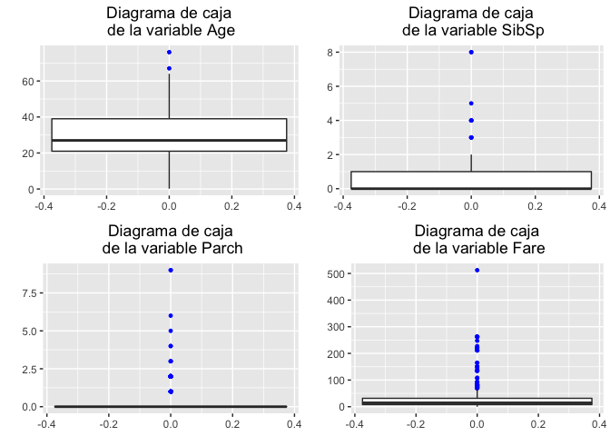

```r
gridExtra::grid.arrange(grobs = lapply(colnames(Filter(is.numeric, test_df[,-1])),
                                       df = test_df,  PrettyBoxplot))
```

### Variable `SibSp`

Los diagramas de caja de la variable `SibSp` muestran que tanto para el conjunto de entrenamiento como para el de evaluación el 75% de los embarcados en el Titanic venían solos o acompañados de un sólo hermano o hermana. Como consecuencia todos los valores más grandes que 3 son numéricamente valores extremos. Para identificar si realmente son valores erróneos que debemos tratar podemos estudiar cuanta gente con más de 3 hermanos comparte el mismo apellido, esta vez sí teniendo en cuenta tanto entrenamiento como evaluación:

```r
# Obtenemos los registros con valores extremos de cada conjunto:
ManySiblingsTrain = train_df[train_df['SibSp']>3, ]
ManySiblingsTest = test_df[test_df['SibSp']>3, ]
# Y los unimos en una sola tabla, eliminando para ello la variable `Survived`:
ManySiblings = rbind(ManySiblingsTrain[, -2], ManySiblingsTest)
# Obtenemos el apellido:
ManySiblings[, 'Surname'] = sapply(ManySiblings[, 'Name'],
                                   function(x){strsplit(x, ",")[[1]][1]})
# Obtenemos la tabla conjunta:
table(ManySiblings[,c('SibSp', 'Surname')])
```

```
##      Surname
## SibSp Andersson Asplund Goodwin Panula Rice Sage
##     4         7       5       0      5    5    0
##     5         0       0       6      0    0    0
##     8         0       0       0      0    0    9
```

Como podemos ver en todos los grupos excepto en el de los apellidados Andersson hay $n+1$ hermanos, donde $n$ es el número de hermanos indicados por cada uno de los hermanos. Consideramos por lo tanto que todos estos valores, aunque extremos, son correctos. Estudiamos con más detalle la familia la familia Andersson:

```r
ManySiblings[ManySiblings['Surname']=='Andersson',]
```

|  | PassengerId | Pclass | Name | Sex | Age | SibSp | Parch | Ticket | Fare | Cabin | Embarked | Surname |
| --- | --- | --- | --- | --- | --- | --- | --- | --- | --- | --- | --- | --- |
| 69 | 69 | 3 | Andersson, Miss. Erna Alexandra | female | 17 | 4 | 2 | 3101281 | 7.925 | NA | S | Andersson |
| 120 | 120 | 3 | Andersson, Miss. Ellis Anna Maria | female | 2 | 4 | 2 | 347082 | 31.275 | NA | S | Andersson |
| 542 | 542 | 3 | Andersson, Miss. Ingeborg Constanzia | female | 9 | 4 | 2 | 347082 | 31.275 | NA | S | Andersson |
| 543 | 543 | 3 | Andersson, Miss. Sigrid Elisabeth | female | 11 | 4 | 2 | 347082 | 31.275 | NA | S | Andersson |
| 814 | 814 | 3 | Andersson, Miss. Ebba Iris Alfrida | female | 6 | 4 | 2 | 347082 | 31.275 | NA | S | Andersson |
| 851 | 851 | 3 | Andersson, Master. Sigvard Harald Elias | male | 4 | 4 | 2 | 347082 | 31.275 | NA | S | Andersson |
| 215 | 1106 | 3 | Andersson, Miss. Ida Augusta Margareta | female | 38 | 4 | 2 | 347091 | 7.775 | NA | S | Andersson |

Como podemos ver hay dos registros que destacan por edad y por billete, los registros 69 y 1106, y que además corresponden a mujeres no están casadas, como indica el título ‘Miss.’. Consideramos por lo tanto que el atributo `SibSp` de estos dos registros es erróneo, y lo convertimos a `NA` (teniendo en cuenta a que conjunto corresponde cada uno):

```r
train_df[train_df[,'PassengerId']==69, 'SibSp'] = NA
test_df[test_df[,'PassengerId']==1106, 'SibSp'] = NA
```

### Variable `Parch`

Los diagramas de caja de la variable `Parch` muestran que numéricamente todos los valores no cero son valores extremos en ambos conjuntos, tanto entrenamiento como evaluación. Estudiamos más en detalle aquellos registros con más de 4 descendientes en el Titanic, y vemos si lo podemos corresponder con las familias de hermanos recién identificadas:

```r
# Obtenemos los registros con valores extremos de cada conjunto:
ManyDescendantsTrain = train_df[train_df['Parch']>4,]
ManyDescendantsTest = test_df[test_df['Parch']>4, ]
# Y los unimos en una sola tabla, eliminando para ello la variable `Survived`:
ManyDescendants = rbind(ManyDescendantsTrain[, -2], ManyDescendantsTest)
# Obtenemos el apellido
ManyDescendants[, 'Surname'] = sapply(ManyDescendants[, 'Name'],
                                      function(x){strsplit(x, ",")[[1]][1]})
# Obtenemos la tabla:
table(ManyDescendants[,c('Parch', 'Surname')])
```

```
##      Surname
## Parch Andersson Asplund Goodwin Panula Rice Sage
##     5         2       2       0      1    1    0
##     6         0       0       2      0    0    0
##     9         0       0       0      0    0    2
```

Como podemos ver se corresponde con las familias identificadas previamente, una vez corregidas los dos registros ‘Andersson’ erróneos, por lo que no son realmente valores extremos.

### Variable `Fare`

En los diagramas de caja de la variable `Fare` vemos que hay muchos valores que numéricamente son valores extremos. En este caso nos limitamos a verificar que todos los registros con tarifa muy elevada son de primera clase:

```r
# Entrenamiento
all(train_df[train_df['Fare']>200,'Pclass'] == 1)
```

```
## [1] TRUE
```

```r
# Evaluación
all(na.omit(test_df[test_df['Fare']>200,'Pclass'] == 1))
```

```
## [1] TRUE
```

Hemos utilizado la función `na.omit()` en el conjunto de evaluación debido al registro con `Fare` desconocido que ya conocemos. Vemos que obviado este valor todos los registros corresponden efectivamente a personas que viajaron en primera clase, por lo que damos los valores de `Fare` por válidos.

## 3.3 Tratamiento de valores nulos

Recapitulando tenemos que tratar

- 263 valores perdidos en la variable `Age`, 177 de entrenamiento y 86 de evaluación,
- 2 valores perdidos en la variable `SibSp`, uno de entrenamiento y otro de evaluación,
- 1 valor perdido en la variable `Fare` en el conjunto de evaluación,
- 1014 valores perdidos en la variable `Cabin`, 687 de entrenamiento y 327 de evaluación, y
- 2 valores perdidos en la variable `Embarked` en el conjunto de entrenamiento.

Es importante notar que todas las medidas que tomemos en este apartado para tratar los valores perdidos deberán tener en cuenta a que subconjunto pertenece cada registro. El motivo es que de lo contrario podríamos estar filtrando información sobre datos de evaluación al modelo, si por ejemplo utilizásemos el conjunto completo para inputar un valor en un registro de entrenamiento.

### Variable `Cabin`

El caso de la variable `Cabin` es el más claro: tanto la variedad de la variable como la cantidad de registros perdidos (casi 3/4) nos obligan a eliminarla de ambos subconjuntos:

```r
train_df = train_df[, colnames(train_df) != 'Cabin']
test_df = test_df[, colnames(test_df) != 'Cabin']
```

Hecho esto resulta interesante estudiar las posibles combinaciones de valores desconocidos, dado que esto dificultara las posibles inputaciones que queramos hacer. Afortunadamente no hay registros con más de un `NA`:

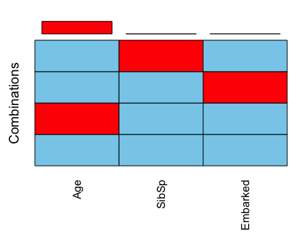

```r
# Entrenamiento
VIM::aggr(Filter(anyNA, train_df[,-2]), combine = TRUE, bars = FALSE)
```

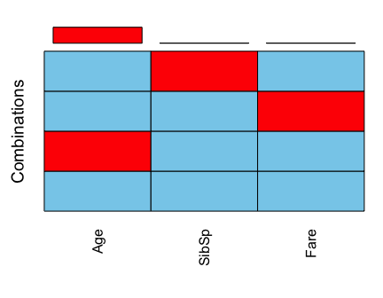

```r
# Evaluación
VIM::aggr(Filter(anyNA, test_df[,-2]), combine = TRUE, bars = FALSE)
```

### Variable `Embarked`

Observemos los registros:

```r
train_df[is.na(train_df['Embarked']),]
```

|  | PassengerId | Survived | Pclass | Name | Sex | Age | SibSp | Parch | Ticket | Fare | Embarked |
| --- | --- | --- | --- | --- | --- | --- | --- | --- | --- | --- | --- |
| 62 | 62 | TRUE | 1 | Icard, Miss. Amelie | female | 38 | 0 | 0 | 113572 | 80 | NA |
| 830 | 830 | TRUE | 1 | Stone, Mrs. George Nelson (Martha Evelyn) | female | 62 | 0 | 0 | 113572 | 80 | NA |

Vemos que compartían billete, pero nadie más lo compartía con ellas:

```r
train_df[train_df['Ticket'] == 113572,]
```

|  | PassengerId | Survived | Pclass | Name | Sex | Age | SibSp | Parch | Ticket | Fare | Embarked |
| --- | --- | --- | --- | --- | --- | --- | --- | --- | --- | --- | --- |
| 62 | 62 | TRUE | 1 | Icard, Miss. Amelie | female | 38 | 0 | 0 | 113572 | 80 | NA |
| 830 | 830 | TRUE | 1 | Stone, Mrs. George Nelson (Martha Evelyn) | female | 62 | 0 | 0 | 113572 | 80 | NA |

Como no tenían familia a bordo tampoco parece que utilizar sus apellidos vaya a ser una buena opción, por lo que decidimos descartar ambos registros:

```r
train_df = train_df[-c(62, 830),]
```

### Variable `Fare`

Observemos el registro:

```r
test_df[is.na(test_df['Fare']),]
```

|  | PassengerId | Pclass | Name | Sex | Age | SibSp | Parch | Ticket | Fare | Embarked |
| --- | --- | --- | --- | --- | --- | --- | --- | --- | --- | --- |
| 153 | 1044 | 3 | Storey, Mr. Thomas | male | 60.5 | 0 | 0 | 3701 | NA | S |

Como el registro pertenece a la tercera clase y no tiene familia embarcada le inputamos la media de tarifas de este subgrupo dentro del subconjunto de evaluación:

```r
test_df[is.na(test_df['Fare']),'Fare']=
  mean(test_df[test_df['Pclass'] == 3 & test_df['SibSp'] == 0 & test_df['Parch'] == 0,
               'Fare'], na.rm = TRUE)
```

### Variable `Age`

Finalmente llegamos a la variable más complicada, `Age`. El número de registros sin edad informada hace inviable eliminarlos todos, por lo que lo más sensato parece tratar de inputarles valores, que nos permite a su vez seguir usando la variable. Utilizaremos para ello una estrategia parecida a la utilizada en [este tutorial de Kaggle](https://www.kaggle.com/allohvk/titanic-missing-age-imputation-tutorial-advanced), inputando los valores de `Age` estratificando los registros según su título (aún por obtener). El “Título” lo extraemos del nombre usando expresiones regulares (*RegEx*), y convertimos a factor:

```r
# Entrenamiento
train_df[, 'Title'] =
  sapply(train_df[, 'Name'], function(x){trimws(strsplit(x, "[,.] ")[[1]][2])})
train_df[, 'Title'] = factor(train_df[, 'Title'])
# Evaluación
test_df[, 'Title'] =
  sapply(test_df[, 'Name'], function(x){trimws(strsplit(x, "[,.] ")[[1]][2])})
test_df[, 'Title'] = factor(test_df[, 'Title'])
```

El código que tenemos encima divide el nombre de cada registro en 3, dividiendo tanto por coma como por punto y elimina los espacios a ambos extremos. La distribución de títulos en los registros con edad informada y aquellos en los que no es como sigue, de manera diferenciada entre entrenamiento y evaluación:

```r
# Entrenamiento, registros con edad informada:
table(droplevels(train_df[!is.na(train_df['Age']), 'Title']))
```

```
##
##         Capt          Col          Don           Dr     Jonkheer         Lady
##            1            2            1            6            1            1
##        Major       Master         Miss         Mlle          Mme           Mr
##            2           36          145            2            1          398
##          Mrs           Ms          Rev          Sir the Countess
##          107            1            6            1            1
```

```r
# Entrenamiento, registros sin edad informada:
table(droplevels(train_df[is.na(train_df['Age']), 'Title']))
```

```
##
##     Dr Master   Miss     Mr    Mrs
##      1      4     36    119     17
```

```r
# Evaluación, registros con edad informada:
table(droplevels(test_df[!is.na(test_df['Age']), 'Title']))
```

```
##
##    Col   Dona     Dr Master   Miss     Mr    Mrs    Rev
##      2      1      1     17     64    183     62      2
```

```r
# Evaluación, registros sin edad informada:
table(droplevels(test_df[is.na(test_df['Age']), 'Title']))
```

```
##
## Master   Miss     Mr    Mrs     Ms
##      4     14     57     10      1
```

Como vemos los títulos de aquellos registros sin edad informada son suficientemente comunes como para ser utilizados en la inputación. La excepción es el registro con título “Ms” del conjunto de evaluación. Tampoco podemos vincularla al una sola categoría de las más pobladas, si no que [podría pertencer tanto a la categoría “Miss” como “Mrs”,](https://en.wikipedia.org/wiki/Ms.) por lo que le asignaremos la edad media de la unión de estas categorías. Este caso especial lo tratamos aparte, para no tener que hacer una excepción en el tratamiento general. Corresponde al `PassengerId`$=980$, como podemos ver a continuación:

```r
test_df[is.na(test_df['Age']) & test_df['Title'] == 'Ms',]
```

|  | PassengerId | Pclass | Name | Sex | Age | SibSp | Parch | Ticket | Fare | Embarked | Title |
| --- | --- | --- | --- | --- | --- | --- | --- | --- | --- | --- | --- |
| 89 | 980 | 3 | O’Donoghue, Ms. Bridget | female | NA | 0 | 0 | 364856 | 7.75 | Q | Ms |

Le asignamos el valor acordado de manera manual:

```r
test_df[test_df['PassengerId'] == 980, 'Age'] =
  mean(test_df[!is.na(test_df['Age']) & (test_df[,'Title'] %in% c("Mrs", "Miss")), 'Age'])
```

Para inputar los valores definimos la siguiente función, que a partir de su `PassegerID` y el subconjunto al que pertenece le asigna a cada registro la media de edad en este subconjunto del resto de registros de su mismo título:

```r
InputeAge = function(PassId, df){
  ToInpute = mean(
    # Filtramos que tengan un valor definido de edad:
    df[!is.na(df['Age'])
       # Filtramos que tengan el mismo título:
       & df['Title'] ==  as.character(df[df['PassengerId']==PassId, 'Title']),
       'Age'])
  return(ToInpute)
}
# Entrenamiento:
train_df[is.na(train_df['Age']), 'Age'] =
  sapply(FUN = InputeAge, X = train_df[is.na(train_df['Age']), 'PassengerId'],
         df = train_df)
# Evaluación:
test_df[is.na(test_df['Age']), 'Age'] =
  sapply(FUN = InputeAge, X = test_df[is.na(test_df['Age']), 'PassengerId'],
         df = test_df)
```

### Variable `SibSp`

Finalmente tratamos los dos valores con `SibSp` sin informar debido a que los hemos considerado valores erróneos en el paso previo de detección de valores extremos. Los registros a tratar son los siguientes:

```r
train_df[is.na(train_df['SibSp']), ]
```

|  | PassengerId | Survived | Pclass | Name | Sex | Age | SibSp | Parch | Ticket | Fare | Embarked | Title |
| --- | --- | --- | --- | --- | --- | --- | --- | --- | --- | --- | --- | --- |
| 69 | 69 | TRUE | 3 | Andersson, Miss. Erna Alexandra | female | 17 | NA | 2 | 3101281 | 7.925 | S | Miss |

```r
test_df[is.na(test_df['SibSp']), ]
```

|  | PassengerId | Pclass | Name | Sex | Age | SibSp | Parch | Ticket | Fare | Embarked | Title |
| --- | --- | --- | --- | --- | --- | --- | --- | --- | --- | --- | --- |
| 215 | 1106 | 3 | Andersson, Miss. Ida Augusta Margareta | female | 38 | NA | 2 | 347091 | 7.775 | S | Miss |

```r
# Entrenamiento
train_inputado = VIM::kNN(train_df,
                          dist_var = c("Pclass", "Age"),
                          variable = 'SibSp')
train_df[train_df['PassengerId']==69, 'SibSp'] =
  train_inputado[train_inputado['PassengerId']==69, 'SibSp']
# Evaluación
test_inputado = VIM::kNN(test_df,
                         dist_var = c("Pclass", "Age"),
                         variable = 'SibSp')
test_df[test_df['PassengerId']==1106, 'SibSp'] =
  test_inputado[test_inputado['PassengerId']==1106, 'SibSp']
```

Los valores inputados son los siguientes, en ambos casos cero como vemos:

```r
train_df[train_df['PassengerId']==69,]
```

|  | PassengerId | Survived | Pclass | Name | Sex | Age | SibSp | Parch | Ticket | Fare | Embarked | Title |
| --- | --- | --- | --- | --- | --- | --- | --- | --- | --- | --- | --- | --- |
| 69 | 69 | TRUE | 3 | Andersson, Miss. Erna Alexandra | female | 17 | 0 | 2 | 3101281 | 7.925 | S | Miss |

```r
test_df[test_df['PassengerId']==1106,]
```

|  | PassengerId | Pclass | Name | Sex | Age | SibSp | Parch | Ticket | Fare | Embarked | Title |
| --- | --- | --- | --- | --- | --- | --- | --- | --- | --- | --- | --- |
| 215 | 1106 | 3 | Andersson, Miss. Ida Augusta Margareta | female | 38 | 0 | 2 | 347091 | 7.775 | S | Miss |

## 3.4 Tratamiento de variables cualitativas con demasiadas categorías

Ahora que hemos concluido la revisión de los valores extremos y los valores desconocidos nos centramos en las categorías de las variables cualitativas. La siguiente tabla muestra el número de categorías de cada variable cualitativa en cada uno de los subconjuntos:

```r
# Entrenamiento
sapply(train_df[, !names(train_df) %in% names(Filter(is.numeric, train_df))],
       function(x){length(unique(x))})
```

```
## Survived   Pclass     Name      Sex   Ticket Embarked    Title
##        2        3      889        2      680        3       17
```

```r
# Evaluación
sapply(test_df[, !names(test_df) %in% names(Filter(is.numeric, test_df))],
       function(x){length(unique(x))})
```

```
##   Pclass     Name      Sex   Ticket Embarked    Title
##        3      418        2      363        3        9
```

Como podemos ver el número de categorías de las variables `Name` y `Ticket` las hace prácticamente inutilizables. En el caso de la variable `Name` además la información más valiosa que aporta, el título, lo hemos recogido ya en la variable `Title`. Por otra parte, viendo la variedad presente en la variable `Ticket` no parece que vayamos a poder extraerle mucha información. Decidimos por lo tanto descartar estas variables:

```r
# Entrenamiento
train_df = train_df[, !names(train_df) %in% c("Name", "Ticket")]
# Evaluación
test_df = test_df[, !names(test_df) %in% c("Name", "Ticket")]
```

La única otra variable relativamente dispersa que queda es precisamente la variable `Title`. Está formada por como mínimo 17 grupos diferentes, pero muchos de ellos corresponden en realidad a grupos sociales similares. Lo podemos ver en las siguientes tablas detallando los distintos niveles y el número de registros en cada uno por conjunto:

```r
# Entrenamiento
table(train_df['Title'])
```

```
##
##         Capt          Col          Don           Dr     Jonkheer         Lady
##            1            2            1            7            1            1
##        Major       Master         Miss         Mlle          Mme           Mr
##            2           40          181            2            1          517
##          Mrs           Ms          Rev          Sir the Countess
##          124            1            6            1            1
```

```r
# Evaluación
table(test_df['Title'])
```

```
##
##    Col   Dona     Dr Master   Miss     Mr    Mrs     Ms    Rev
##      2      1      1     21     78    240     72      1      2
```

Podemos incluir las categorías más pequeñas en las más grandes categorías como sigue:

- Fundimos los registros con título “Capt”, “Col”, “Don”, “Dr”, “Jonkheer”, “Major”, “Rev” y “Sir” en la categoría “Mr”, dado que todos se refieren a hombres adultos.
- Fundimos los registros con título “Dona”, “Mme” y “the Countess” en la categoría “Mrs”, dado que todos hacen referencia a mujeres casadas.
- Fundimos los registros con título “Lady”, “Ms” y “Mlle” en la categoría “Miss”, dado que todos hacen referencia a mujeres sin casar.

Lo hacemos mediante el siguiente código:

```r
# Entrenamiento
train_df[train_df[,'Title'] %in%
           c("Capt", "Col", "Don", "Dr", "Jonkheer", "Major", "Rev", "Sir"), 'Title'] = "Mr"
train_df[train_df[,'Title'] %in%
           c("Dona", "Mme", "the Countess"), 'Title'] = "Mrs"
train_df[train_df[,'Title'] %in%
           c("Lady", "Ms", "Mlle"), 'Title'] = "Miss"
# Evaluación
test_df[test_df[,'Title'] %in%
          c("Capt", "Col", "Don", "Dr", "Jonkheer", "Major", "Rev", "Sir"), 'Title'] = "Mr"
test_df[test_df[,'Title'] %in%
          c("Dona", "Mme", "the Countess"), 'Title'] = "Mrs"
test_df[test_df[,'Title'] %in%
          c("Lady", "Ms", "Mlle"), 'Title'] = "Miss"
```

Eliminamos de la variable `Title` las categorías ahora sin usar y volvemos a mostrar la tabla con la cantidad de registros en cada:

```r
# Entrenamiento
train_df[,'Title'] = droplevels(train_df['Title'])
table(train_df['Title'])
```

```
##
## Master   Miss     Mr    Mrs
##     40    185    538    126
```

```r
# Evaluación
test_df[,'Title'] = droplevels(test_df['Title'])
table(test_df['Title'])
```

```
##
## Master   Miss     Mr    Mrs
##     21     79    245     73
```

Como podemos ver ahora la variable consta sólo de 4 categorías y todas ellas están suficientemente pobladas. Es importante notar que si bien este método reduce la información que la variable puede ofrecer, también evita que registros pertenecientes a categorías poco pobladas tengan una predicción poco segura, al estar basada en tan pocos registros.

También es interesante ver que la variable `Title` condensa ahora dos informaciones: el sexo y la edad.

## 3.5 Resultado y exportación de datos limpios

Vemos como no queda ningún registro con valores desconocidos en los datos:

```r
# NA's en conjunto de entrenamiento:
sum(sapply(train_df, is.na))
```

```
## [1] 0
```

```r
# NA's en conjunto de evaluación:
sum(sapply(test_df, is.na))
```

```
## [1] 0
```

También exportamos los datos ya integrados, validados y limpiados a dos nuevos ficheros: “train_clean.csv” y “test_clean.csv”:

```r
write.csv(train_df, "data/train_clean.csv", row.names = FALSE)
write.csv(test_df, "data/test_clean.csv", row.names = FALSE)
```

# 4. Análisis de los datos

Recordemos que a partir de este apartado sólo utilizaremos el conjunto de entrenamiento, guardado en la tabla `train_df`.

## 4.1 Planificación del análisis y selección de los grupos de datos a analizar

Planteamos las siguientes preguntas a responder:

1. ¿Siguen las variables cuantitativas una distribución normal? ¿Se da la homogeneidad de varianzas entre supervivientes y no supervivientes?
2. Si dividimos la muestra en supervivientes y no supervivientes, ¿hay diferencia en la media de las variables numéricas?
3. ¿Hay correlación entre las variables numéricas?
4. ¿En cuales de los factores varía de forma significativa el ratio de supervivencia según la categoría?
5. Entrenamos un modelo que prediga la supervivencia en base al resto de variables. ¿Cómo de bueno es el modelo obtenido?¿Cuales son las variables más importantes a la hora de predecir la supervivencia?

Dado que para responder a estas preguntas utilizaremos todas las variables en el conjunto de datos no hace falta que seleccionemos variables; por otra parte dado que en las preguntas b) y d) distinguimos según supervivientes y no supervivientes sí que resulta interesante filtrar el conjunto de datos en función del valor de la variable `Survived`:

```r
DidSurvive = train_df[train_df[,'Survived'] == TRUE,]
DidNotSurvive = train_df[train_df[,'Survived'] == FALSE,]
```

## 4.2 (Pregunta a) ¿Siguen las variables cuantitativas una distribución normal?¿Se da la homogeneidad de varianzas entre supervivientes y no supervivientes?

Comprobamos la normalidad de las variables numéricas en el conjunto de datos: las variables `Age`, `SibSp`, `Parch` y `Fare`. Como el tamaño muestral es mayor que 50 utilizaremos el test de Kolmogorov-Smirnov. Usaremos también un valor $\alpha = 0.05$ para decidir si aceptar o rechazar la hipótesis nula. Los resultados son los siguientes:

```r
# Age
ks.test(train_df[,'Age'], pnorm, mean(train_df[,'Age']), sd(train_df[,'Age']))
```

```
##
##  One-sample Kolmogorov-Smirnov test
##
## data:  train_df[, "Age"]
## D = 0.10129, p-value = 2.395e-08
## alternative hypothesis: two-sided
```

```r
# SibSp
ks.test(train_df[,'SibSp'], pnorm, mean(train_df[,'SibSp']), sd(train_df[,'SibSp']))
```

```
##
##  One-sample Kolmogorov-Smirnov test
##
## data:  train_df[, "SibSp"]
## D = 0.36484, p-value < 2.2e-16
## alternative hypothesis: two-sided
```

```r
# Parch
ks.test(train_df[,'Parch'], pnorm, mean(train_df[,'Parch']), sd(train_df[,'Parch']))
```

```
##
##  One-sample Kolmogorov-Smirnov test
##
## data:  train_df[, "Parch"]
## D = 0.44268, p-value < 2.2e-16
## alternative hypothesis: two-sided
```

```r
# Fare
ks.test(train_df[,'Fare'], pnorm, mean(train_df[,'Fare']), sd(train_df[,'Fare']))
```

```
##
##  One-sample Kolmogorov-Smirnov test
##
## data:  train_df[, "Fare"]
## D = 0.28257, p-value < 2.2e-16
## alternative hypothesis: two-sided
```

El resultado es claro: como los p-valores son todos menores que $\alpha = 0.05$ concluímos que ninguna de nuestras variables sigue una distribución normal.

Como ninguna de las variables ha resultado normal utilizamos el test de Fligner-Killeen, adecuado en estos casos, para determinar la homocedasticidad según los grupos definidos por la variable respuesta `Survived`. Los resultados son los siguientes:

```r
# Age
fligner.test(Age~Survived, data = train_df)
```

```
##
##  Fligner-Killeen test of homogeneity of variances
##
## data:  Age by Survived
## Fligner-Killeen:med chi-squared = 6.3622, df = 1, p-value = 0.01166
```

```r
# SibSp
fligner.test(SibSp~Survived, data = train_df)
```

```
##
##  Fligner-Killeen test of homogeneity of variances
##
## data:  SibSp by Survived
## Fligner-Killeen:med chi-squared = 1.0677, df = 1, p-value = 0.3015
```

```r
# Parch
fligner.test(Parch~Survived, data = train_df)
```

```
##
##  Fligner-Killeen test of homogeneity of variances
##
## data:  Parch by Survived
## Fligner-Killeen:med chi-squared = 11.57, df = 1, p-value = 0.0006704
```

```r
# Fare
fligner.test(Fare~Survived, data = train_df)
```

```
##
##  Fligner-Killeen test of homogeneity of variances
##
## data:  Fare by Survived
## Fligner-Killeen:med chi-squared = 94.7, df = 1, p-value < 2.2e-16
```

En este test las conclusiones ya no son uniformes: para $\alpha = 0.05$ los p-valores obtenidos nos indican que en las variable `Age`, `Parch` y `Fare` no hay uniformidad de varianzas, pero en la variable `SibSp` sí.

## 4.3 Aplicación de pruebas estadísticas para comparar los grupos de datos

### Pregunta b) Si dividimos la muestra en supervivientes y no supervivientes, ¿hay diferencia en la media de las variables numéricas?

A pesar de que como hemos visto las variables numéricas en nuestro conjunto de datos no son normales aún pueden ser útiles a la hora de predecir la supervivencia. Una pregunta que cabe hacerse en este sentido es si hay diferencia en estas variables entre la muestra formada por supervivientes y la muestra formada por no supervivientes.

Es necesario comentar que aunque las variables no sigan una distribución normal el tener una muestra mayor que 30 junto con el Teorema del Límite Central nos permiten utilizar el Test de la t de Student. Lo aplicamos a continuación teniendo en cuenta los resultados de los test de homocedasticidad del anterior apartado:

```r
# Age
t.test(DidSurvive[, 'Age'], DidNotSurvive[, 'Age'])
```

```
##
##  Welch Two Sample t-test
##
## data:  DidSurvive[, "Age"] and DidNotSurvive[, "Age"]
## t = -2.7605, df = 664.36, p-value = 0.00593
## alternative hypothesis: true difference in means is not equal to 0
## 95 percent confidence interval:
##  -4.4034058 -0.7429019
## sample estimates:
## mean of x mean of y
##  28.11087  30.68402
```

```r
# SibSp
t.test(DidSurvive[, 'SibSp'], DidNotSurvive[, 'SibSp'], var.equal = TRUE)
```

```
##
##  Two Sample t-test
##
## data:  DidSurvive[, "SibSp"] and DidNotSurvive[, "SibSp"]
## t = -1.1755, df = 887, p-value = 0.2401
## alternative hypothesis: true difference in means is not equal to 0
## 95 percent confidence interval:
##  -0.23766939  0.05961303
## sample estimates:
## mean of x mean of y
## 0.4647059 0.5537341
```

```r
# Parch
t.test(DidSurvive[, 'Parch'], DidNotSurvive[, 'Parch'])
```

```
##
##  Welch Two Sample t-test
##
## data:  DidSurvive[, "Parch"] and DidNotSurvive[, "Parch"]
## t = 2.5219, df = 752.59, p-value = 0.01188
## alternative hypothesis: true difference in means is not equal to 0
## 95 percent confidence interval:
##  0.0305685 0.2453449
## sample estimates:
## mean of x mean of y
## 0.4676471 0.3296903
```

```r
# Fare
t.test(DidSurvive[, 'Fare'], DidNotSurvive[, 'Fare'])
```

```
##
##  Welch Two Sample t-test
##
## data:  DidSurvive[, "Fare"] and DidNotSurvive[, "Fare"]
## t = 6.7597, df = 433.18, p-value = 4.483e-11
## alternative hypothesis: true difference in means is not equal to 0
## 95 percent confidence interval:
##  18.50519 33.67804
## sample estimates:
## mean of x mean of y
##  48.20950  22.11789
```

Una vez más vemos que para $\alpha= 0.05$ los resultados son claros: mientras que en las variables `Age`, `Parch` y `Fare` si hay una diferencia significativa en la media entre aquellos que sobrevivieron y aquellos que no, en la variable `SibSp` el test arroja que no hay una diferencia significativa.

Es importante notar que si bien hemos visto que en la variable `SibSp`no se nota una diferencia significativa en al media dependiendo de la supervivencia, esto no quiere decir que por ejemplo un árbol de decisión vaya a considerar esta variable inútil con toda certeza: es posible que sí que sea útil al interaccionar con el resto de variables.

### Pregunta c) ¿Hay correlación entre las variables numéricas?

De cara a la posibilidad de obtener un modelo logístico en la pregunta e) resulta también de interés estudiar la correlación entre las variables numéricas del conjunto.

Calculamos primero la correlación entre las variables numéricas del conjunto. Usamos la correlación de Spearman, debido a la no normalidad de nuestras variables:

```r
cor(Filter(is.numeric, train_df[,-1]), method = "spearman")
```

```
##              Age      SibSp      Parch      Fare
## Age    1.0000000 -0.1682600 -0.2421005 0.1081318
## SibSp -0.1682600  1.0000000  0.4442208 0.4541662
## Parch -0.2421005  0.4442208  1.0000000 0.4131056
## Fare   0.1081318  0.4541662  0.4131056 1.0000000
```

Como podemos ver hay una correlación moderada pero definitivamente significativa entre las variables `SibSp`, `Parch` y `Fare`. La variable `Age` está también correlacionada con las otras 3, pero en menor medida. En consecuencia usamos el test para la correlación entre variables para verificar si la correlación de la variable `Age` con cada una de las otras variables es estadísticamente significativa:

```r
# Age vs. Parch
cor.test(train_df[,"Age"], train_df[,"SibSp"])
```

```
##
##  Pearson's product-moment correlation
##
## data:  train_df[, "Age"] and train_df[, "SibSp"]
## t = -8.1778, df = 887, p-value = 9.959e-16
## alternative hypothesis: true correlation is not equal to 0
## 95 percent confidence interval:
##  -0.3248774 -0.2025573
## sample estimates:
##        cor
## -0.2647821
```

```r
# Age vs. Parch
cor.test(train_df[,"Age"], train_df[,"Parch"])
```

```
##
##  Pearson's product-moment correlation
##
## data:  train_df[, "Age"] and train_df[, "Parch"]
## t = -5.9489, df = 887, p-value = 3.882e-09
## alternative hypothesis: true correlation is not equal to 0
## 95 percent confidence interval:
##  -0.2582992 -0.1318210
## sample estimates:
##        cor
## -0.1958745
```

```r
# Age vs. Parch
cor.test(train_df[,"Age"], train_df[,"Fare"])
```

```
##
##  Pearson's product-moment correlation
##
## data:  train_df[, "Age"] and train_df[, "Fare"]
## t = 2.6359, df = 887, p-value = 0.008537
## alternative hypothesis: true correlation is not equal to 0
## 95 percent confidence interval:
##  0.02254084 0.15302569
## sample estimates:
##        cor
## 0.08816146
```

Como podemos ver todos los p-valores son inferiores a $\alpha = 0.05$, por lo que podemos concluir que todas las variables están significativamente correlacionadas entre sí.

### Pregunta d) ¿En cuales de los factores varía de forma significativa el ratio de supervivencia según la categoría?

Estudiamos ahora si hay diferencias significativas de supervivencia entre distintas categorías de los factores. Utilizamos para ello un test de igualdad de proporciones, de supervivientes en nuestro caso.

```r
ApplyPropTest = function(var){
  case.vector = as.vector(table(DidSurvive[, var]))
  total.cases = as.vector(table(train_df[,var]))
  cat(paste("Test for equality of proportions of variable", var, ":\n"))
  print(prop.test(case.vector, total.cases))
}
```

```r
ApplyPropTest('Pclass')
```

```
## Test for equality of proportions of variable Pclass :
##
##  3-sample test for equality of proportions without continuity
##  correction
##
## data:  case.vector out of total.cases
## X-squared = 100.98, df = 2, p-value < 2.2e-16
## alternative hypothesis: two.sided
## sample estimates:
##    prop 1    prop 2    prop 3
## 0.2423625 0.4728261 0.6261682
```

```r
ApplyPropTest('Sex')
```

```
## Test for equality of proportions of variable Sex :
##
##  2-sample test for equality of proportions with continuity correction
##
## data:  case.vector out of total.cases
## X-squared = 258.43, df = 1, p-value < 2.2e-16
## alternative hypothesis: two.sided
## 95 percent confidence interval:
##  0.4908118 0.6121411
## sample estimates:
##    prop 1    prop 2
## 0.7403846 0.1889081
```

```r
ApplyPropTest('Embarked')
```

```
## Test for equality of proportions of variable Embarked :
##
##  3-sample test for equality of proportions without continuity
##  correction
##
## data:  case.vector out of total.cases
## X-squared = 26.489, df = 2, p-value = 1.77e-06
## alternative hypothesis: two.sided
## sample estimates:
##    prop 1    prop 2    prop 3
## 0.5535714 0.3896104 0.3369565
```

```r
ApplyPropTest('Title')
```

```
## Test for equality of proportions of variable Title :
##
##  4-sample test for equality of proportions without continuity
##  correction
##
## data:  case.vector out of total.cases
## X-squared = 287.81, df = 3, p-value < 2.2e-16
## alternative hypothesis: two.sided
## sample estimates:
##    prop 1    prop 2    prop 3    prop 4
## 0.5750000 0.7027027 0.1617100 0.7936508
```

Como podemos ver la respuesta es unánime: en todos los factores debemos rechazar la hipótesis nula de igualdad de proporciones. Concluimos por lo tanto que en todos los factores el ratio de supervivencia varía dependiendo de la categoría.

### Pregunta e) Entrenamos un modelo que prediga la supervivencia en base al resto de variables. ¿Cómo de bueno es el modelo obtenido?¿Cuales son las variables más importantes a la hora de predecir la supervivencia?

Para responder a esta pregunta recapitulamos las conclusiones obtenidas hasta ahora:

- Hemos visto que ninguna de nuestras variables numéricas sigue una distribución normal, y también que todas ellas están significativamente correlacionadas. Esto las hace poco adecuadas para un modelo logístico, que asume ambas condiciones.
- Hemos visto que las variables `Age`, `Fare` y `Parch` tienen una media significativamente diferente cuando comparamos a supervivientes y no supervivientes. Con la variable `SibSp` en cambio esto no pasa, lo cual no quita que no sean predictivas si las hacemos interactuar con otras variables.
- Hemos visto que la proporción de supervivientes entre las distintas categorías de cada una de las variables cualitativas es significativamente diferente.

Las primeras dos conclusiones sugieren claramente que un modelo logístico puede no funcionar bien. La segunda además nos indica en particular que debemos utilizar algún modelo que tenga en cuenta interacciones de variables. La solución más intuitiva es utilizar un árbol de decisión para intentar predecir la supervivencia en función del resto de variables incluidas en el conjunto de datos, como mínimo en un primer modelo.

```r
library(caret)
set.seed(5)
# La función train() requiere modificar los niveles de la variable `Survived`:
Survived =
  factor(train_df[,"Survived"], levels = c(FALSE, TRUE), labels = c("Died", "Survived"))
# Número de pliegues:
folds = 5
# Índices del muestreo estratificado:
cvIndex = createFolds(Survived, k = folds, returnTrain = T)
# Especificamos que se haga una validación cruzada con k = folds,
# que devuelva también la probabilidad de cada clase y la función resumen a utilizar:
ctrl = trainControl(index = cvIndex,
                    method = 'cv',
                    number = folds,
                    summaryFunction = twoClassSummary,
                    classProbs = T,
                    savePredictions = T)
# Especificamos también que los modelos sean árboles (no reglas),
# que se aplique podado y que no haya "boosting":
tuneGrid = expand.grid(.winnow = TRUE, .trials=1, .model="tree")
# Entremos el modelo:
C5fit = train(x = train_df[,-(1:2)], y = Survived,
              tuneGrid = tuneGrid, trControl = ctrl,
              method = "C5.0", metric = "ROC")
```

Estudiemos las medidas de rendimiento obtenidas mediante la validación cruzada:

```r
# Imprimimos los resultados de la validación cruzada:
print(C5fit)
```

```
## C5.0
##
## 889 samples
##   8 predictor
##   2 classes: 'Died', 'Survived'
##
## No pre-processing
## Resampling: Cross-Validated (5 fold)
## Summary of sample sizes: 711, 711, 711, 711, 712
## Resampling results:
##
##   ROC        Sens       Spec
##   0.8281687  0.9053545  0.65
##
## Tuning parameter 'trials' was held constant at a value of 1
## Tuning
##  parameter 'model' was held constant at a value of tree
## Tuning
##  parameter 'winnow' was held constant at a value of TRUE
```

Como los modelos obtenidos son buenos podemos entrenar un nuevo modelo con toda la muestra de entrenamiento, que el proceso de validación cruzada indica que será bueno también, y tomar las variables más utilizadas por este modelo como las más predictivas. La propia función `train()` crea un modelo final con todo el conjunto de entrenamiento, y la función `varImp()` nos devuelve la proporción de registros afectados por cada una de las variables en este modelo (como indicador de su importancia):

```r
# Imprimimos las variables más importantes:
varImp(C5fit)
```

```
## C5.0 variable importance
##
##          Overall
## Title     100.00
## SibSp      39.48
## Pclass     39.48
## Age        15.41
## Embarked   14.06
## Fare        0.00
## Sex         0.00
## Parch       0.00
```

Como podemos ver la variable más determinante es `Title`, seguida en mucha menor medida por `SibSp` y `Pclass`, y con la ayuda también de las variables `Age` y `Embarked`. Las variables `Fare`, `Parch` y `Sex` no se han mostrado apenas relevantes: su importancia no ha superado el mínimo para considerarse positiva, en parte debido al *pruning* (podado de ramificaciones) que hemos aplicado. Aún así debemos tener en cuenta en nuestro análisis de resultados que la variable `Title` contiene información del sexo y la edad, y lo mismo ocurre con la variable `Pclass`, que resume (grosso modo) la información de la variable `Fare`.

El modelo final obtenido entrenando con todo conjunto de entrenamiento es el siguiente:

```r
# Imprimimos la información del modelo final:
cat(C5fit$finalModel$output)
```

```
##
## C5.0 [Release 2.07 GPL Edition]      Mon Jun  7 22:12:16 2021
## -------------------------------
##
## Class specified by attribute `outcome'
##
## Read 889 cases (9 attributes) from undefined.data
##
## 2 attributes winnowed
## Estimated importance of remaining attributes:
##
##      84%  Sex
##      21%  SibSp
##       9%  Title
##       8%  Pclass
##       6%  Age
##      <1%  Embarked
##
## Decision tree:
##
## Title = Mr: Died (538/87)
## Title in {Master,Miss,Mrs}:
## :...SibSp > 2:
##     :...Pclass = 3: Died (35/3)
##     :   Pclass in [2-1]: Survived (3)
##     SibSp <= 2:
##     :...Pclass in [2-1]: Survived (176/9)
##         Pclass = 3:
##         :...Age > 38: Died (12/1)
##             Age <= 38:
##             :...Embarked in {C,Q}: Survived (58/15)
##                 Embarked = S:
##                 :...Title = Miss: Died (41/18)
##                     Title in {Master,Mrs}: Survived (26/8)
##
##
## Evaluation on training data (889 cases):
##
##      Decision Tree
##    ----------------
##    Size      Errors
##
##       8  141(15.9%)   <<
##
##
##     (a)   (b)    <-classified as
##    ----  ----
##     517    32    (a): class Died
##     109   231    (b): class Survived
##
##
##  Attribute usage:
##
##  100.00% Title
##   39.48% Pclass
##   39.48% SibSp
##   15.41% Age
##   14.06% Embarked
##
##
## Time: 0.0 secs
```

Es interesante observar que la primera división podría verse también como combinación de sexo y edad: indica que los hombres adultos murieron en su gran mayoría.

# 5. Representación de los resultados

## 5 a) Representación de la no normalidad de los datos

Para representar de manera gráfica la no normalidad de los datos dibujamos gráficas de tipo cuantil-cuantil (para la distribución normal en este caso) y histogramas para cada una de las variables numéricas:

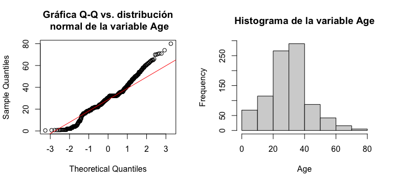

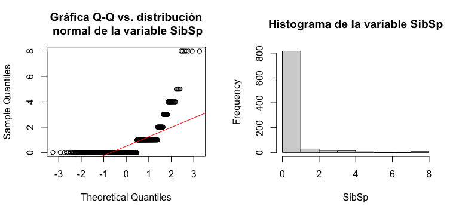

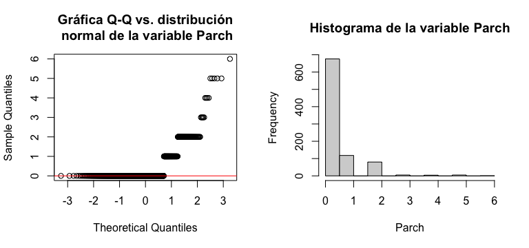

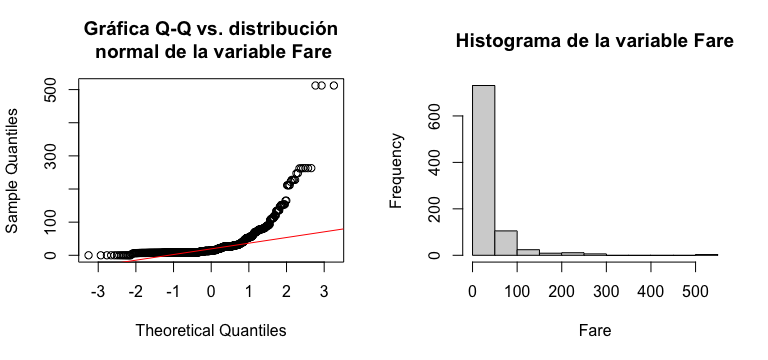

```r
# Fijamos la disposición de gráficas a 2 por fila:
par(mfrow = c(1,2))
# Iteramos sobre las variables numéricas
for(var in colnames(Filter(is.numeric, train_df[,-1]))) {
  # Añadimos los puntos:
  qqnorm(train_df[, var],
         main = paste("Gráfica Q-Q vs. distribución\n normal de la variable",
                      var))
  # Añadimos la línea:
  qqline(train_df[, var], col="red")
  # Añadimos el histograma:
  hist(train_df[, var],
       main = paste("Histograma de la variable", var),
       xlab = var)
}
```

Observando estas gráficas es claro porque los tests han rechazado que estas variables sigan una distribución normal.

## 5 b) Representación de las medias de las variables cuantitativas según la supervivencia

Podemos representar de manera gráfica el Test de la t de Student dibujando los intervalos de confianza sobre la media de cada variable númerica según la supervivencia:

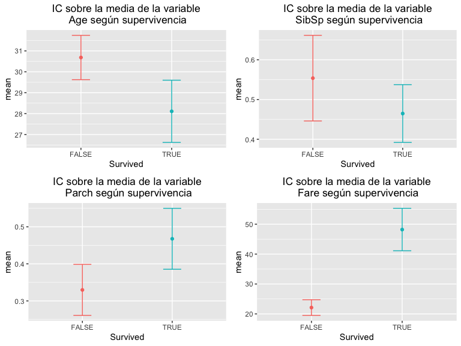

```r
library(dplyr)

MeanPlot = function(var){
  # Obtenemos un nuevo dataframe con la media y la desviación estándar
  aux_df = train_df %>% group_by(Survived) %>% dplyr::summarise(
    n = n(),
    mean = mean(get(var)),
    sd = sd(get(var)))

  # Dibujamos el gráfico:
  ggplot(aux_df, aes(x=Survived, y=mean, group=Survived, color=Survived)) +
    geom_point() +geom_errorbar(aes(ymin=mean-1.96*sd/sqrt(n), ymax=mean+1.96*sd/sqrt(n)),
                                width=.2, position=position_dodge(0.05)) +
    ggtitle(paste("IC sobre la media de la variable\n", var, "según supervivencia")) +
    theme(plot.title = element_text(hjust = 0.5), legend.position="none") +
    scale_fill_manual(values = c("red3", "green2"))
}
gridExtra::grid.arrange(grobs = lapply(colnames(Filter(is.numeric, train_df[,-1])), MeanPlot))
```

## 5 c) Representación de la correlación entre las variables numéricas

Representamos la correlación entre las variables numéricas del conjunto de datos tanto de forma numérica como con una representación elipsoidal usando ela librería `corrplot`:

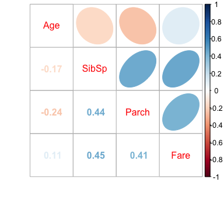

```r
corrplot::corrplot.mixed(
  cor(Filter(is.numeric, train_df[,-1]), method = "spearman"),
  lower = "number", upper = "ellipse")
```

## 5 d) Representación del ratio de supervivencia según categoría de las variables cualitativas

A continuación representamos el ratio de supervivencia según la categoría de cada una de las variables cualitativas estudiadas:

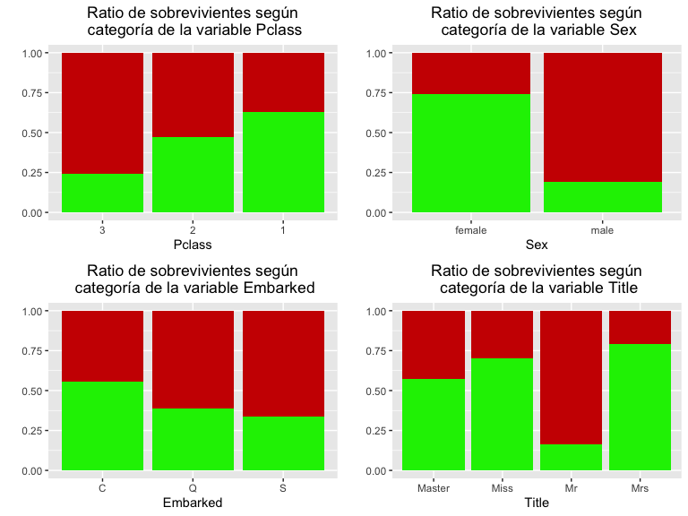

```r
FillPlots= function(var1){
  bp = ggplot(data=train_df, aes(x=get(var1), fill=Survived)) + geom_bar(position = "fill") +
    ggtitle(paste("Ratio de sobrevivientes según\n categoría de la variable", var1)) +
    ylab("") + xlab(var1) +
    theme(plot.title = element_text(hjust = 0.5), legend.position="none") +
    scale_fill_manual(values = c("red3", "green2"))
  return(bp)
}

gridExtra::grid.arrange(grobs = lapply(colnames(Filter(is.factor, train_df[,-(1:2)])), FillPlots))
```

Vemos que efectivamente hay diferencias significativas en todas las variables.

## 5 e) Representación del la importancia de las variables en la predicción

Finalmente representamos las variables más importantes encontradas mediante validación cruzada de árboles de decisión:

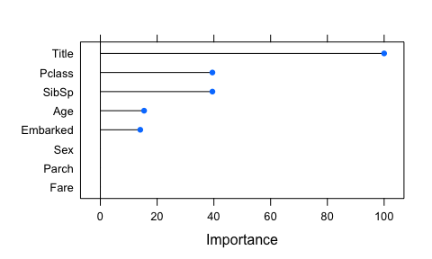

```r
plot(varImp(C5fit))
```

Representamos también la curva ROC del modelo final con toda la muestra de entrenamiento:

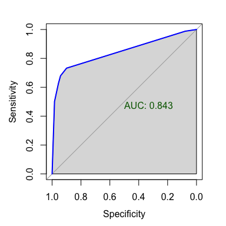

```r
pROC::plot.roc(as.numeric(train_df$Survived)-1,
               predict(C5fit$finalModel, train_df, type="prob")[,2],
               col = "blue", print.auc.col = "darkgreen",
               print.auc = TRUE, identity = TRUE, auc.polygon=TRUE)
```

*Nota:* si bien aquí sería interesante dibujar el árbol obtenido mediante el código `plot(C5fit$finalModel)`, parece haber algún nuevo tipo de incompatibilidad entre las librerías `C50` y `partykit` impidiéndolo.

# 6. Resolución del problema y conclusiones

Hemos extraído las siguientes conclusiones del análisis:

- Hemos visto que las variables numéricas no siguen una distribución normal, y además estaban correlacionadas. Por otra parte hemos encontrado diferencias significativas en la media de las submuestras de supervivientes y no supervivientes, lo cual nos indicaba que podía ser interesante utilizarlas en la predicción.
- Hemos visto que había diferencias significativas en la proporción de supervivientes entre las diferentes categorías de las variables categóricas.
- Hemos realizado una estimación del AUC en evaluación utilizando validación cruzada obteniendo un valor de $0.83$. Hemos entrenado también un árbol de decisión C5.0 sobre la muestra de entrenamiento completa y obtenido un AUC de $0.84$.
- Como el valor del AUC del modelo final es bueno hemos asumido que las variables más importantes a la hora de predecir la supervivencia en el dataset Titanic son las que este modelo ha encontrado más importantes: `Title`, `SibSp`, `Pclass`, `Age` y `Embarked`.

Concluimos por lo tanto que hemos cumplido de forma satisfactoria los objetivos marcados.

# 7. Código

El fichero RMarkdown (.rmd) origen de este documento está disponible para descarga en el siguiente enlace de Github:

https://github.com/ander-elkoroaristizabal/Titanic/blob/main/source/Titanic_analysis.Rmd

Este documento está disponible en 3 formatos:

- [Formato Markdown](https://github.com/ander-elkoroaristizabal/Titanic/blob/main/source/Titanic_analysis.md), que puede leerse directamente en Github.
- [Formato pdf](https://github.com/ander-elkoroaristizabal/Titanic/blob/main/source/Titanic_analysis.pdf).
- [Formato html](https://github.com/ander-elkoroaristizabal/Titanic/blob/main/source/Titanic_analysis.html).

Los datos finales analizados están en la carpeta `data` del repositorio, más concretamente el siguiente enlace:

https://github.com/ander-elkoroaristizabal/Titanic/blob/main/data/train_clean.csv